# Machine Learning of the Barbell Exercise Activity

Neal S

### Abstract

We describe how we used machine learning techniques to model a dataset taken from subjects performing barbell exercises. Subjects performed the exercises with accelerometers attached to them to record body movements and were asked to perform the exercises both correctly and incorrectly. The dataset contains a variable denoting whether or not the exercise was performed correctly. Our model predicts, from the testing data, if the exercise is being performed correctly or not based on the accelerometer data.

### The Data Set

The dataset contains accelerometer data from a group of subjects performing barbell exercises. There are 160 different variables in the training data representing all sorts of accelerometer readings as well as the standard identification of subject and test run. Most of the data is quite boring and doesn’t lend itself to visual inspection, so we’ll forego any plotting that might help us visualize and understand the data. Most importantly, however, is the outcome variable *classe* which is categorical and contains values “A” to “E”. That outcome is what we will train our model to predict.

A visual inspection of the data in tabular form reveals large gaps in many of the variables, so some pruning might be necessary. Furthermore, it is noted that the provided test dataset has values for only 60 of the original 160 variables. Since we have fixed sets of testing and training data, we can immediately remove those variables from both sets. They will do nothing to help us evaluate (and by extension, train) our model. If we were given one dataset to partition ourselves into testing and training sets, then we would keep any variables that had valid entries for both testing and training sets.

```r
library(caret)
library(randomForest)

# Load the data and remove invalid data columns
trainData <- read.csv('pml-training.csv', na.strings=c("NA", ""))
testData <- read.csv('pml-testing.csv', na.strings=c("NA", ""))

good.cols <- (colSums(is.na(testData)) != nrow(testData))

# Note columns are identical in each except for the last (which has data)
testData <- testData[, good.cols]
trainData <- trainData[, good.cols]
```

Fortunately, after removing those 100 columns, both datasets now appear to contain complete cases. This makes training easier. Additionally, we noticed that the provided test set does not contain the outcome variable. This of course makes it unusable to us for testing purposes. That particular dataset was designed for some other purpose so we will partition the provided *training* dataset into our own train and test data.

### The Model

We’ve chosen a random forest model because it has proven to be reasonably accurate when predicting categorical variables. We partition the dataset into 80% training and 20% testing. We’ve also introduced cross validation to give a better estimate of model error. With such a large number of samples, cross validation is possible without too much worry of over-fitting.

```r
set.seed(621)

# create a partition for train & test
train.rows <- createDataPartition(y = trainData$classe, p=0.8, list=FALSE)

# re-assign our train & test datasets to the new partitions
testData <- trainData[-train.rows,]
trainData <- trainData[train.rows,]

x <- trainData[,8:59]
y <- trainData$classe
```

```
##          52          26          13           6           3           1
## 0.005669151 0.007580101 0.010128034 0.043569654 0.114593286 0.610484744
```

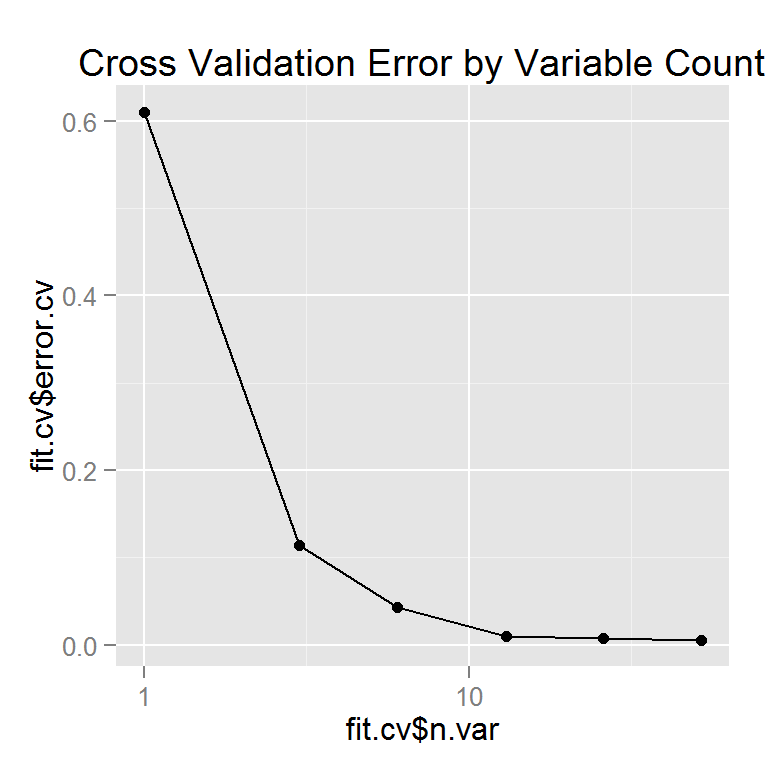

```r
# cross-validation prediction performance of reduced predictors.
# this takes 9 minutes
fit.cv <- rfcv(x, factor(y), cv.fold=5)
print(fit.cv$error.cv)

# this plot shows that 15 variables should be enough
qplot(fit.cv$n.var, fit.cv$error.cv, log="x", type="o") +
    geom_line() + ggtitle('Cross Validation Error by Variable Count')
```

```r
# Train the final model. This takes 50 seconds
fit <- randomForest(x, factor(y), mtry=15)
```

### Prediction Results

Below is a matrix of our model’s predictive results on our test dataset. One can see that it correctly classified almost every sample in the testing data set, giving it an overall **accuracy greater than 0.99**. That’s quite amazing but also a bit scary. With accuracy that high there is a fear that we may have over-fitted our model. However, we re-ran the experiment several times which tells us show that overfitting is not the case; perhaps this particular problem is just easily classified.

```r
pred <- predict(fit, newdata=testData)
cf <- confusionMatrix(pred, testData$classe)
print(cf)
```

```
## Confusion Matrix and Statistics
##
##           Reference
## Prediction    A    B    C    D    E
##          A 1116    2    0    0    0
##          B    0  756    2    0    0
##          C    0    1  682    4    2
##          D    0    0    0  638    0
##          E    0    0    0    1  719
##
## Overall Statistics
##
##                Accuracy : 0.9969
##                  95% CI : (0.9947, 0.9984)
##     No Information Rate : 0.2845
##     P-Value [Acc > NIR] : < 2.2e-16
##
##                   Kappa : 0.9961
##  Mcnemar's Test P-Value : NA
##
## Statistics by Class:
##
##                      Class: A Class: B Class: C Class: D Class: E
## Sensitivity            1.0000   0.9960   0.9971   0.9922   0.9972
## Specificity            0.9993   0.9994   0.9978   1.0000   0.9997
## Pos Pred Value         0.9982   0.9974   0.9898   1.0000   0.9986
## Neg Pred Value         1.0000   0.9991   0.9994   0.9985   0.9994
## Prevalence             0.2845   0.1935   0.1744   0.1639   0.1838
## Detection Rate         0.2845   0.1927   0.1738   0.1626   0.1833
## Detection Prevalence   0.2850   0.1932   0.1756   0.1626   0.1835
## Balanced Accuracy      0.9996   0.9977   0.9975   0.9961   0.9985
```

### Conclusion

The random forest methods prove to be quite useful in these types of classification problems.